# R Notebook

# Filtering data with different thresholds:

Per meting on 9-6-2018, filtering the community dataset to a subset of species may greatly improve the relevance + significance of our result.

Key “levers” to manipulate:

- Normalization of cover values - dividing matrix values by row total
  - Maximum (total) cover = 1
- Mean cover in control
  - Mean cover in control plot over the observed sampling period
- Persistence in control
  - Number of observations of a species in control over the observed sampling period
- Present in year 0 for control and at least one nutrient treatment
  - Observations in initial year that may influence detrending

And correlations between between.

# Tuning function:

The tuning function produces a new datatable (tuningtable) that contains information on the relevant variables we discussed selecting species by. It’s a modular function, so if we need to add more variables or treatments in our subsetting, it’s easy to do so.

I think the easiest way to use this table is to select a number of thresholds, filter the table by these thresholds, then use a left_join to filter the LRR data to just those relevant species.

Some of the key variables to pull from this dataset are:

- Persistence in control - the total number of observations in control divided by the number of years
- Mean cover in control - the average recorded cover in control treatments over the duration of sampling, including years with no observations (given a “0”)
- Representation in the first year of sampling - the total number of plots where a species was observed in year 0, pre-treatment.

The first few rows of the table are as follows:

|  | X | site_code | block | nyears | firstyear | lastyear | Taxon | totalobs | tot_obsControl | mean_covControl | tot_obsN | mean_covN | tot_obsP | mean_covP | tot_obsK | mean_covK | tot_obsFence | mean_covFence | tot_obsNPK | mean_covNPK | tot_obsNPK...Fence | mean_covNPK...Fence | total_pret_obs | pret_obsControl | pret_covControl | pret_obsN | pret_covN | pret_obsP | pret_covP | … |
| --- | --- | --- | --- | --- | --- | --- | --- | --- | --- | --- | --- | --- | --- | --- | --- | --- | --- | --- | --- | --- | --- | --- | --- | --- | --- | --- | --- | --- | --- | --- |
| 1 | 1 | azi.cn | 1 | 5 | 2007 | 2012 | ACONITUM SP. | 1 | 0 | 0.000 | 0 | 0.000000000 | 0 | 0.0000 | 1 | 0.0000 | 0 | 0.00000000 | 0 | 0.0000 | 0 | 0 | 1 | 0 | 0.00 | 0 | 0.00 | 0 | 0.00 | … |
| 2 | 2 | azi.cn | 1 | 5 | 2007 | 2012 | AGROSTIS STOLONIFERA | 24 | 5 | 0.068 | 4 | 0.100000000 | 4 | 0.0350 | 3 | 0.0300 | 4 | 0.06250000 | 4 | 0.0575 | 0 | 0 | 6 | 1 | 0.06 | 1 | 0.03 | 1 | 0.01 | … |
| 3 | 3 | azi.cn | 1 | 5 | 2007 | 2012 | ALLIUM CHRYSANTHUM | 20 | 5 | 0.004 | 3 | 0.006666667 | 4 | 0.0125 | 4 | 0.0125 | 3 | 0.01666667 | 1 | 0.0100 | 0 | 0 | 4 | 1 | 0.00 | 1 | 0.00 | 1 | 0.01 | … |
| 4 | 4 | azi.cn | 1 | 5 | 2007 | 2012 | ANAPHALIS HANCOCKII | 2 | 0 | 0.000 | 0 | 0.000000000 | 0 | 0.0000 | 0 | 0.0000 | 1 | 0.02000000 | 1 | 0.0100 | 0 | 0 | 0 | 0 | 0.00 | 0 | 0.00 | 0 | 0.00 | … |
| 5 | 5 | azi.cn | 1 | 5 | 2007 | 2012 | ANAPHALIS LACTEA | 1 | 0 | 0.000 | 0 | 0.000000000 | 1 | 0.0100 | 0 | 0.0000 | 0 | 0.00000000 | 0 | 0.0000 | 0 | 0 | 0 | 0 | 0.00 | 0 | 0.00 | 0 | 0.00 | … |
| 6 | 6 | azi.cn | 1 | 5 | 2007 | 2012 | ANEMONE OBTUSILOBA | 29 | 5 | 0.024 | 4 | 0.020000000 | 5 | 0.0240 | 5 | 0.0340 | 5 | 0.01800000 | 5 | 0.0220 | 0 | 0 | 6 | 1 | 0.03 | 1 | 0.01 | 1 | 0.03 | … |

# Column Names in TuningTable

Site_code, block, plot as before

New columns:

**Plot level**

- nyears - Number of years of observations (plot)
- firstyear - First year of observation (plot)
- lastyear - Last year of observation (plot)

**Taxon level**

- Taxon - Taxon name
- totalobs - Total number of observations in block, over time
- tot_obsControl - Total number of observations in control plot
- mean_covControl - Mean cover in control plot, all years
- tot_obsN - Total number of observations in +N plot
- mean_covN - Mean cover in +N plot, all years
- tot_obsP - Total number of observations in +P plot
- mean_covP - Mean cover in control +P, all years
- tot_obsK - Total number of observations in +K plot
- mean_covK - Mean cover in +K plot, all years
- tot_obsFence - Total number of observations in +Fence plot
- mean_covFence - Mean cover in +Fence plot, all years
- tot_obsNPK - Total number of observations in +NPK plot
- mean_covNPK - Mean cover in +NPK plot, all years
- tot_obsNPK + Fence - Total number of observations in +NPK + Fence plot
- mean_covNPK + Fence - Mean cover in +NPK + Fence plot, all years

**Pretreatment, Taxon level**

- total_pret_obs - Total number of observations in block, first year
- pret_obsControl - Observation in control plot, first year (1/0)
- pret_covControl - Cover in control plot, first year
- pret_obsN - Observation in +N plot, first year (1/0)
- pret_covN - Cover in +N plot, first year
- pret_obsP - Observation in +P plot, first year (1/0)
- pret_covP - Cover in +P plot, first year
- pret_obsK - Observation in +K plot, first year (1/0)
- pret_covK - Cover in +K plot, first year
- pret_obsFence - Observation in +Fence plot, first year (1/0)
- pret_covFence - Cover in +Fence plot, first year
- pret_obsNPK - Observation in +NPK plot, first year (1/0)
- pret_covNPK - Cover in +NPK plot, first year
- pret_obsNPK + Fence - Observation in +NPK + Fence plot, first year (1/0)
- pret_covNPK + Fence - Cover in +NPK + Fence plot, first year

**As an aside, some of the sites don’t seem to be behaving well:**

The unique years recorded does not always seem to equal the first year subtracted from the last year, + 1. Is this the result of years where no live species are recorded in a plot?

**Offending sites:**

```
## [1] "azi.cn"    "barta.us"  "hogone.us" "pinj.au"
```

# Correlations among measures:

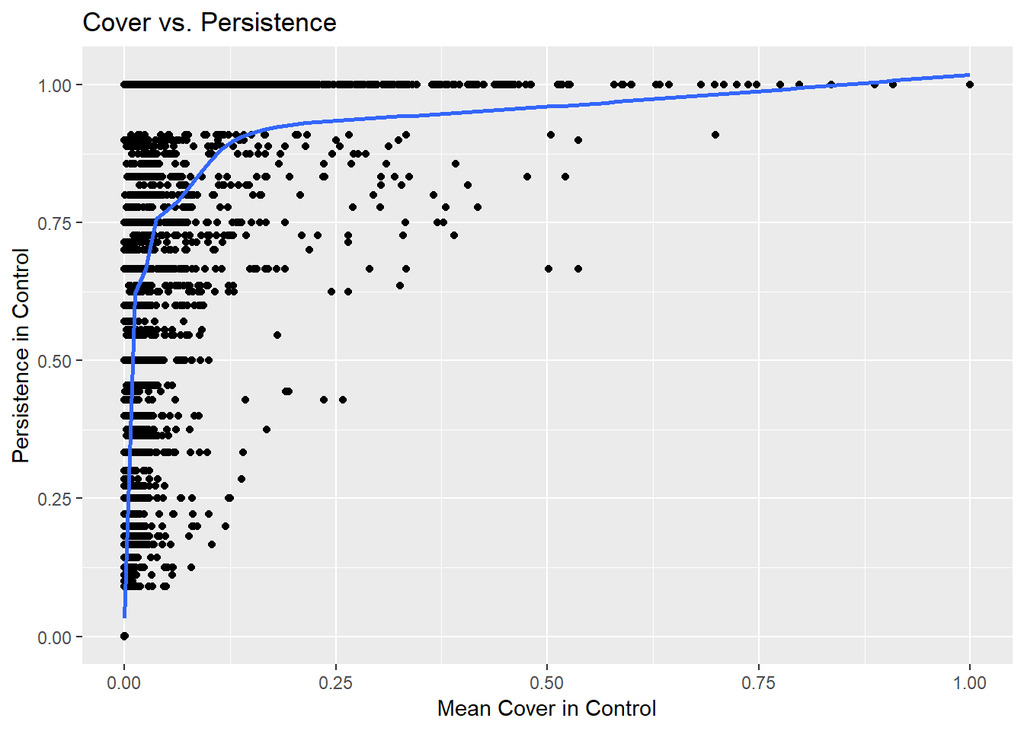

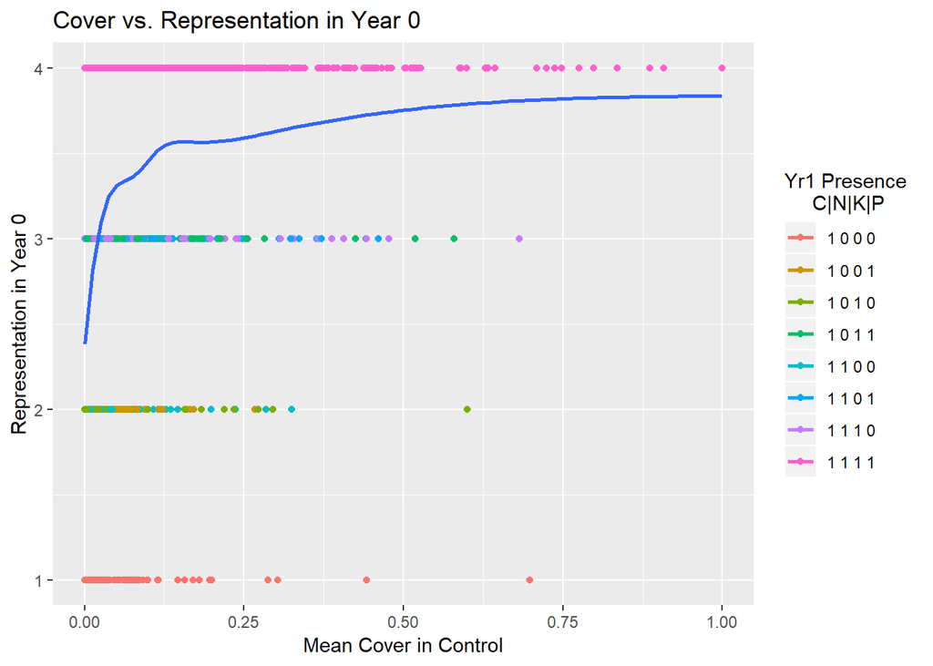

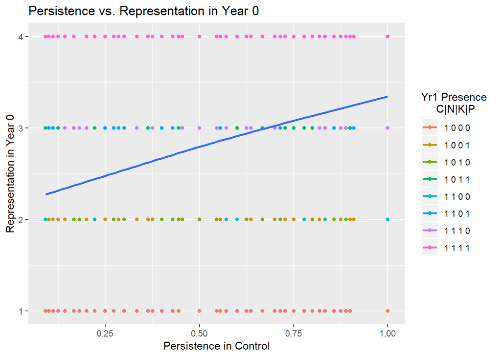

# LRR Sensitivity to Filtering Approaches

To see how the use of these different tuning parameters, I’ve constructed a series of figures that subset your LRR output based on the tuning table. It’s a bit messy, but provides some good indication of threshold values for filtering.

Because many of the filtering variables are correlated, the results are quite similar as we get more selective.

## Varying mean cover

**Parameters held constant:**

- Persistence = .2
- Initial representation in plots = 4 (all treatment plots)

**NOTE: ALL PLOTS FACETTED BY YEAR**

```
## Mean cover =  0
```

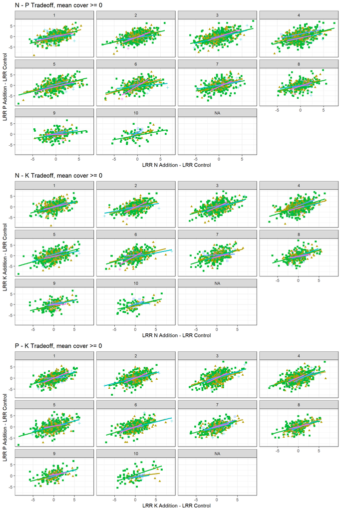

```
## Mean cover =  0.25
```

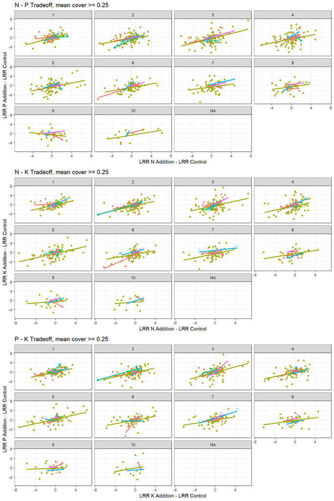

```
## Mean cover =  0.5
```

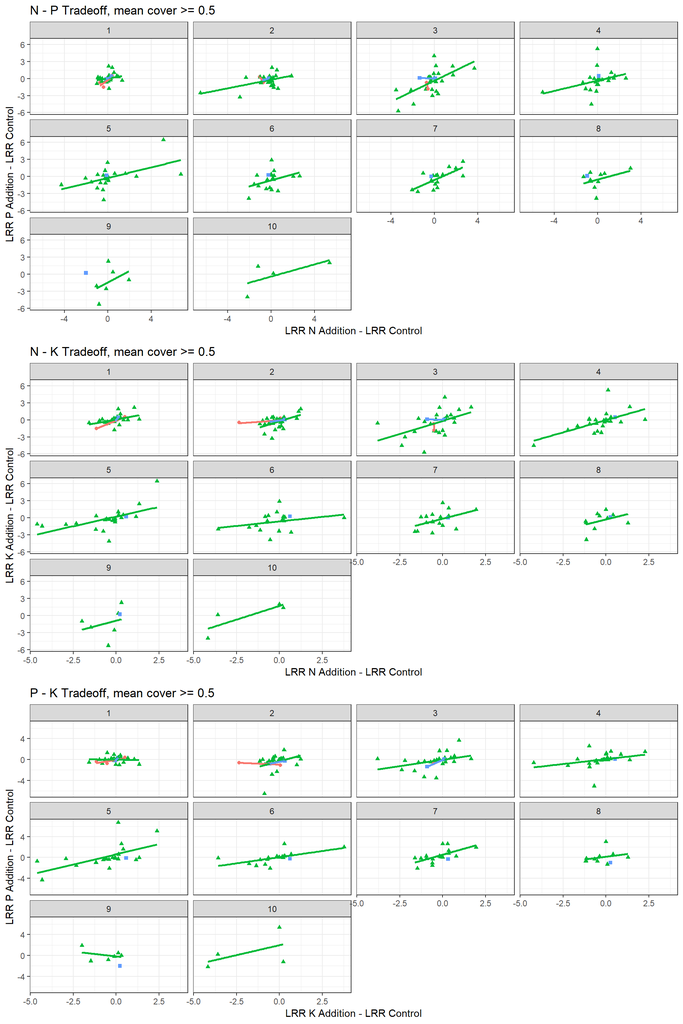

## Varying persistence

**Parameters held constant:**

- Mean cover = .05
- Initial representation in plots = 4 (all treatment plots)

```
## Persistence =  0.25
```

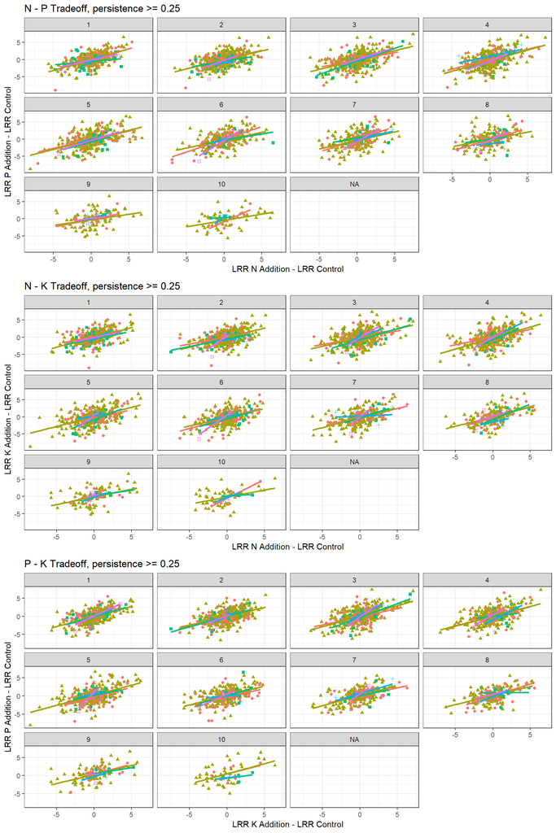

```
## Persistence =  0.5
```

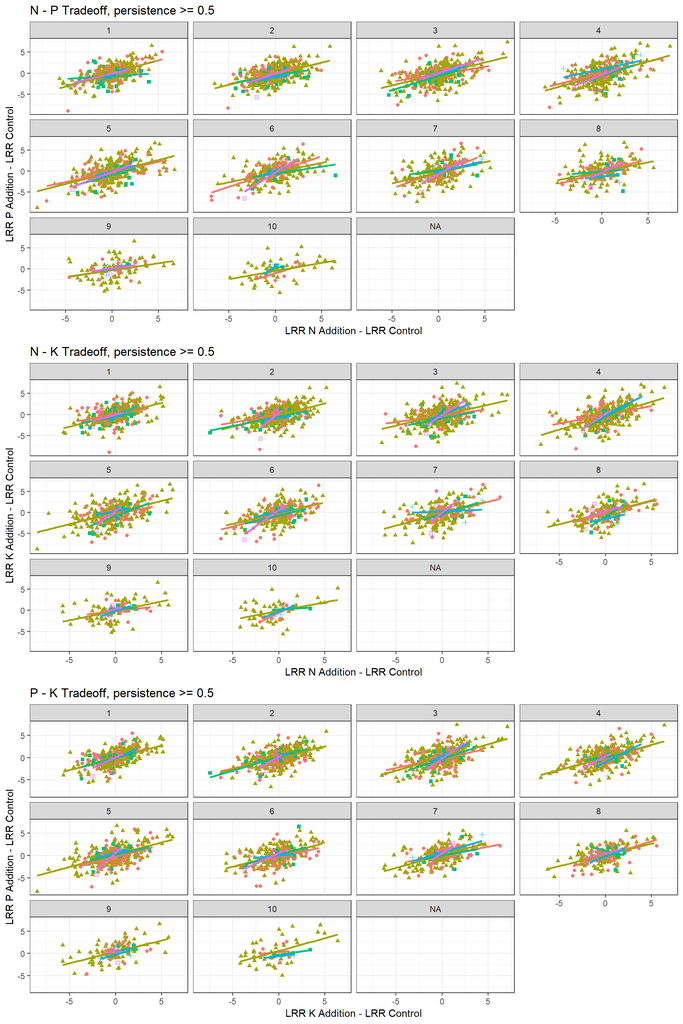

```
## Persistence =  0.75
```

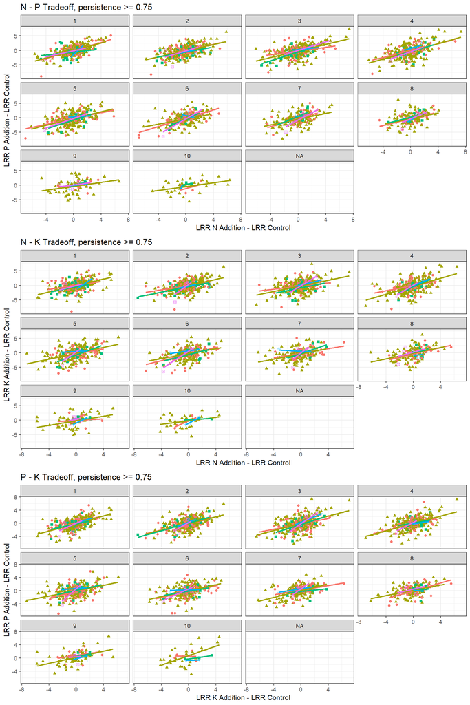

```
## Persistence =  1
```

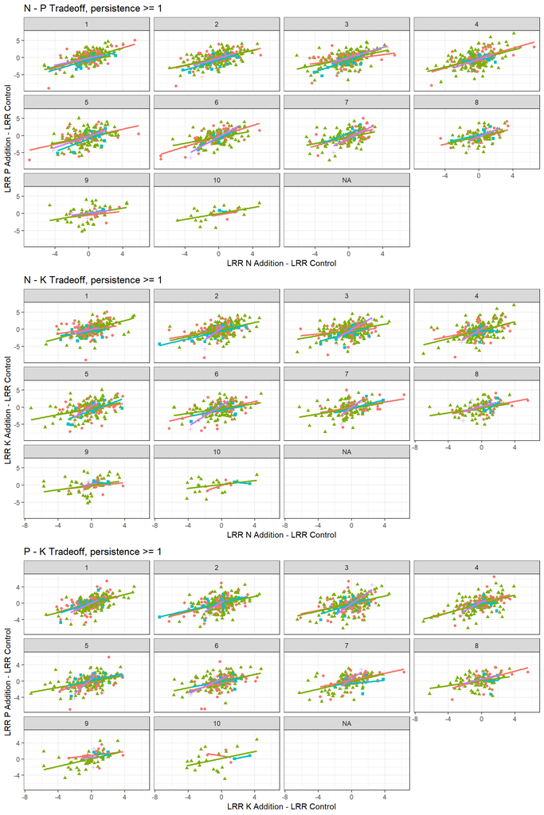

## Varying initial representation

**Parameters held constant:**

- Mean cover = .05
- Persistence = .2

```
## Initial Representation =  1
```

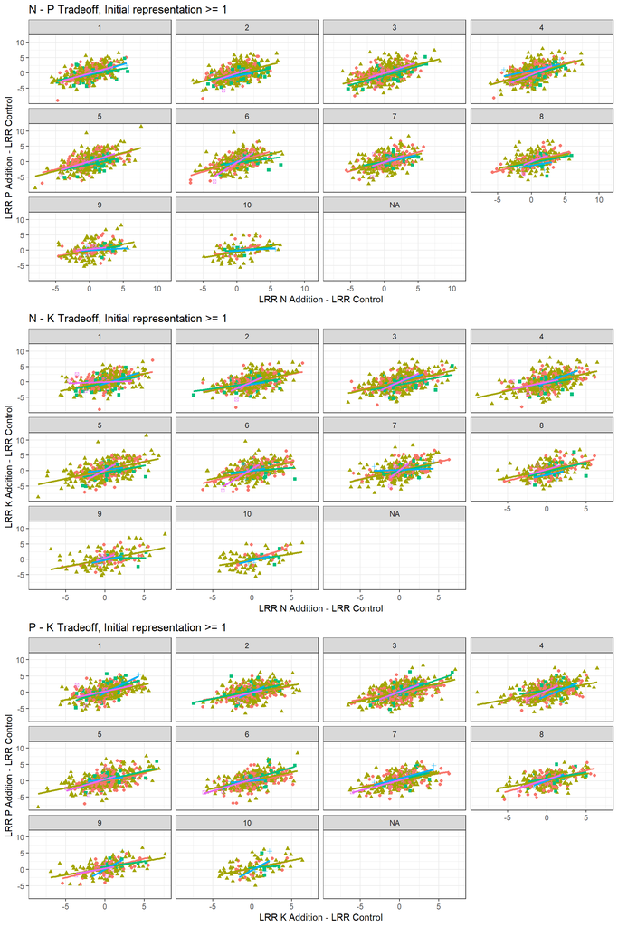

```
## Initial Representation =  2
```

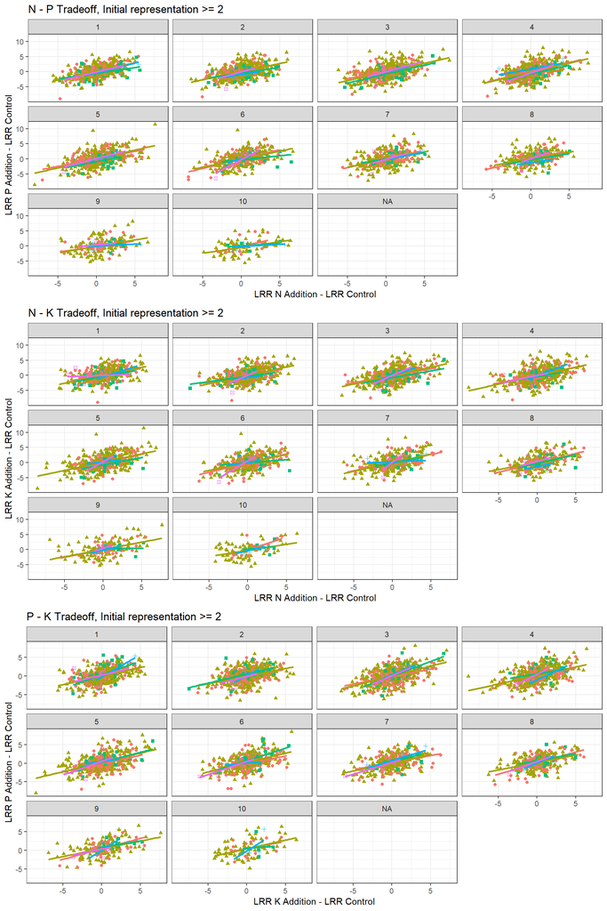

```
## Initial Representation =  3
```

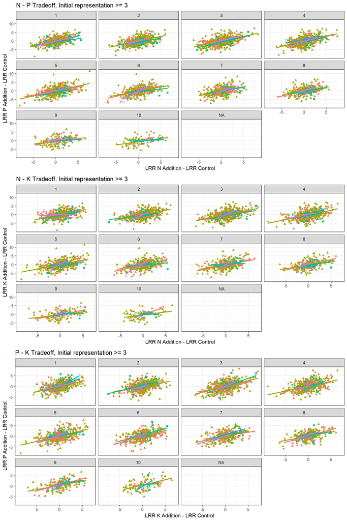

```
## Initial Representation =  4
```

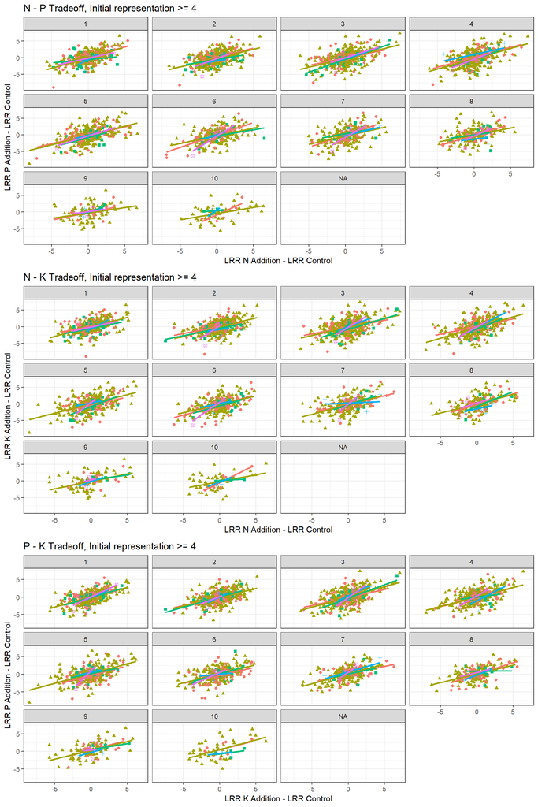

# Removing detrending correction:

**Parameters held constant:**

- Mean cover = .05
- Persistence = .2
- Initial representation in year 0 = 4

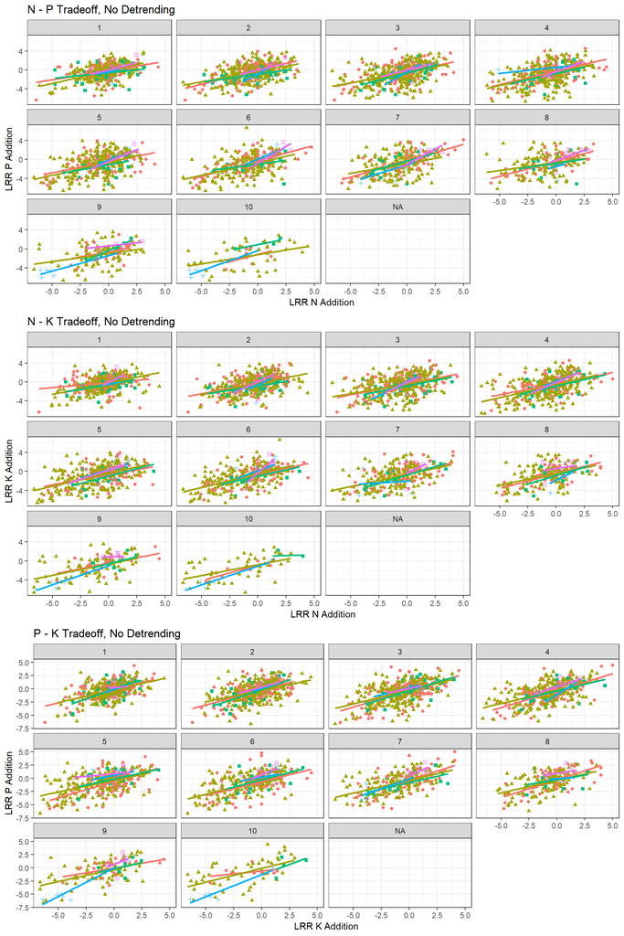